# Area_Height_Analysis

Steve Rolfe

5 November 2015

Standard code to clear the system and install required libraries

```r
rm(list=ls())
library(ggplot2)
library(lubridate)
library(dplyr)
library(zoo)
```

Set up standard files names and the subset to plot

```r
setwd("C:/Users/Steve Rolfe/Google Drive/Phenomics/Area_Height")
input_file="./data/BR7_area_ht.csv"
plant_codes="./data/BR7_plant_codes.csv"

output_file="./output/BR7_area_ht_output.csv"


#subset of data to plot using grep format
#sset<-"BR7-0[1]1[1][1-4]"
sset<-"BR7-0[1-5]1[1-3][1-4]"
```

```r
#rolling window size - for the rolling average of water data
wsz<-3
#maximum window size - for the number of points from which to calculate the maximum
msz<-3
#how close to the maximum value does a value have to be to be counted as a maximum
csz<-0.95
```

Set up standard headers for the files - these need to be edited to be consistent The BR codes are suppled by IBERS but we should include the ASSYT codes where possible Standard headers should be BR_code,date_time, measurements (with informative names) Custom code will be needed to translate the BR_codes into useful information

Read in the data and check that the required headers are there

```r
#read in the data
htdata<-read.csv(input_file,header=TRUE,stringsAsFactors = FALSE)
if(is.object(htdata)==FALSE) {stop(c("Can't open file:",input_file))}

#check that there the required headings are there and throw an error if not
if(is.na(match("BR_code",colnames(htdata)))){stop("BR_code missing from input file header")}
if(is.na(match("date_time",colnames(htdata)))){stop("date_time missing from input file header")}
head(htdata)
```

```
##    date_time   BR_code Plant_height_px Pot_width Plant_height_mm Total_px
## 1 2015-07-17 BR7-01111             116       500              35    10852
## 2 2015-07-18 BR7-01111             223       500              67    16777
## 3 2015-07-19 BR7-01111             183       500              55    19087
## 4 2015-07-24 BR7-01111             292       500              88    79427
## 5 2015-07-26 BR7-01111             259       500              78   113081
## 6 2015-07-27 BR7-01111             290       500              87   132719
##   Area_mm2 Yellow.px
## 1      977       433
## 2     1510       382
## 3     1718       212
## 4     7148      1037
## 5    10177      1103
## 6    11945      1300
```

```r
#this file contains info about the plants used
plant_codes<-read.csv(plant_codes,header = TRUE,stringsAsFactors = FALSE)
if(is.object(plant_codes)==FALSE) {stop(c("Can't open file:",plant_codes))}
```

We deal with any specific coding here about names of plants, spores etc. Use the file plant_codes to keep the information organised

```r
#dpi offset from first data point
#it's good to express everything as dpi but 1st data point might not be dpi
#set the date of infection
dpi_datetime<-"2015-7-6 00:00:00"

#now set the factors manually
htdata$BR_code<-as.factor(htdata$BR_code)

#and set the plants,spores,etc
#the plant code is the sixth character in the BR7 string
htdata$plant<-as.factor(substr(htdata$BR_code,6,6))
#the spore concentration code is the 8th character
htdata$spore<-as.factor(substr(htdata$BR_code,8,8))
#the repeat is the 9th
htdata$rep<-as.factor(substr(htdata$BR_code,9,9))
head(htdata)
```

```
##    date_time   BR_code Plant_height_px Pot_width Plant_height_mm Total_px
## 1 2015-07-17 BR7-01111             116       500              35    10852
## 2 2015-07-18 BR7-01111             223       500              67    16777
## 3 2015-07-19 BR7-01111             183       500              55    19087
## 4 2015-07-24 BR7-01111             292       500              88    79427
## 5 2015-07-26 BR7-01111             259       500              78   113081
## 6 2015-07-27 BR7-01111             290       500              87   132719
##   Area_mm2 Yellow.px plant spore rep
## 1      977       433     1     1   1
## 2     1510       382     1     1   1
## 3     1718       212     1     1   1
## 4     7148      1037     1     1   1
## 5    10177      1103     1     1   1
## 6    11945      1300     1     1   1
```

```r
#now merge the plant names with the data frame
htdata<-merge(htdata,plant_codes,by.x="plant",by.y="plant_code")
head(htdata)
```

```
##   plant  date_time   BR_code Plant_height_px Pot_width Plant_height_mm
## 1     1 2015-08-19 BR7-01111             846       500             254
## 2     1 2015-08-20 BR7-01111             863       500             259
## 3     1 2015-08-22 BR7-01111             865       500             260
## 4     1 2015-08-23 BR7-01111             829       500             249
## 5     1 2015-08-24 BR7-01111             859       500             258
## 6     1 2015-08-21 BR7-01111             821       500             246
##   Total_px Area_mm2 Yellow.px spore rep  plant_name    ASSYST
## 1   827294    74456     80474     1   1 OSR Cracker Sheff-001
## 2   800705    72063    144407     1   1 OSR Cracker Sheff-001
## 3   667552    60080     19037     1   1 OSR Cracker Sheff-001
## 4   649326    58439     20417     1   1 OSR Cracker Sheff-001
## 5   684931    61644     26818     1   1 OSR Cracker Sheff-001
## 6   726149    65353    111656     1   1 OSR Cracker Sheff-001
```

```r
#now do some standard time processing
#use difftime to get the days since inoculation
htdata$dpi<-as.numeric(difftime(htdata$date_time,dpi_datetime,units="days"))
```

Always use a subset function to keep things under control for plotting

```r
subdata<-subset(htdata,grepl(sset,htdata$BR_code))
subdata<-droplevels(subdata)
#there's a lot of missing data (with NAs) so get rid
subdata<-na.omit(subdata)
```

Now plot the basic data

```r
head(subdata)
```

```
##   plant  date_time   BR_code Plant_height_px Pot_width Plant_height_mm
## 1     1 2015-08-19 BR7-01111             846       500             254
## 2     1 2015-08-20 BR7-01111             863       500             259
## 3     1 2015-08-22 BR7-01111             865       500             260
## 4     1 2015-08-23 BR7-01111             829       500             249
## 5     1 2015-08-24 BR7-01111             859       500             258
## 6     1 2015-08-21 BR7-01111             821       500             246
##   Total_px Area_mm2 Yellow.px spore rep  plant_name    ASSYST dpi
## 1   827294    74456     80474     1   1 OSR Cracker Sheff-001  44
## 2   800705    72063    144407     1   1 OSR Cracker Sheff-001  45
## 3   667552    60080     19037     1   1 OSR Cracker Sheff-001  47
## 4   649326    58439     20417     1   1 OSR Cracker Sheff-001  48
## 5   684931    61644     26818     1   1 OSR Cracker Sheff-001  49
## 6   726149    65353    111656     1   1 OSR Cracker Sheff-001  46
```

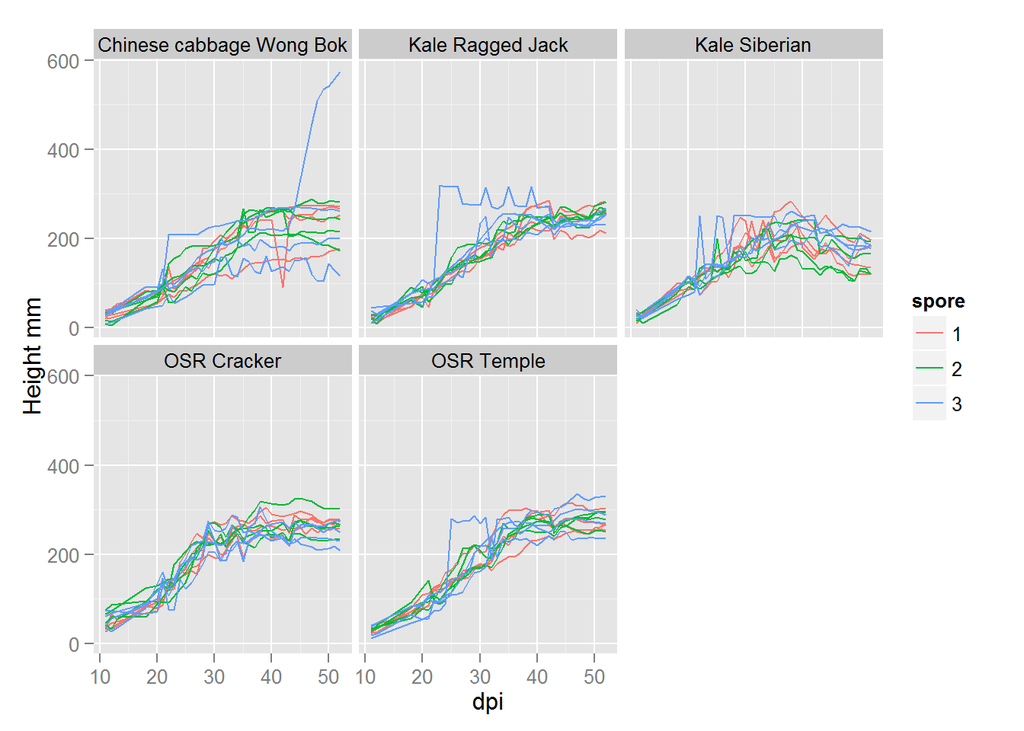

```r
#plot the raw height data as a line
p1<-ggplot(data=subdata,aes(x=dpi,y=Plant_height_mm,color=spore,group=BR_code))+geom_line()
p1<-p1+scale_y_continuous(name="Height mm")
p1<-p1+facet_wrap(~plant_name)
p1
```

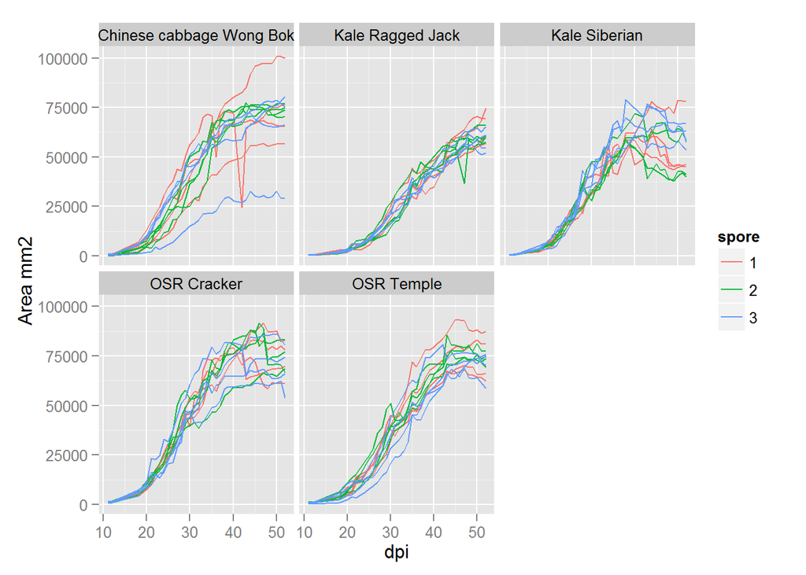

```r
#plot the area
p2<-ggplot(data=subdata,aes(x=dpi,y=Area_mm2,color=spore,group=BR_code))+geom_line()
p2<-p2+scale_y_continuous(name="Area mm2")
p2<-p2+facet_wrap(~plant_name)
p2
```

Try a rolling average for the area data

```r
#sort the data so that the rolling means and cumulative values are correct
subdata<-subdata[with(subdata,order(BR_code,dpi)),]
#get the rolling average by group (window = wsz)
subdata$area_ravg<-ave(subdata$Area_mm2,subdata$BR_code,FUN=function(x) rollmean(x,k=wsz,fill = NA,na.pad=T))
head(subdata)
```

```
##    plant  date_time   BR_code Plant_height_px Pot_width Plant_height_mm
## 13     1 2015-07-17 BR7-01111             116       500              35
## 14     1 2015-07-18 BR7-01111             223       500              67
## 15     1 2015-07-19 BR7-01111             183       500              55
## 16     1 2015-07-24 BR7-01111             292       500              88
## 17     1 2015-07-26 BR7-01111             259       500              78
## 18     1 2015-07-27 BR7-01111             290       500              87
##    Total_px Area_mm2 Yellow.px spore rep  plant_name    ASSYST dpi
## 13    10852      977       433     1   1 OSR Cracker Sheff-001  11
## 14    16777     1510       382     1   1 OSR Cracker Sheff-001  12
## 15    19087     1718       212     1   1 OSR Cracker Sheff-001  13
## 16    79427     7148      1037     1   1 OSR Cracker Sheff-001  18
## 17   113081    10177      1103     1   1 OSR Cracker Sheff-001  20
## 18   132719    11945      1300     1   1 OSR Cracker Sheff-001  21
##    area_ravg
## 13        NA
## 14  1401.667
## 15  3458.667
## 16  6347.667
## 17  9756.667
## 18 13279.000
```

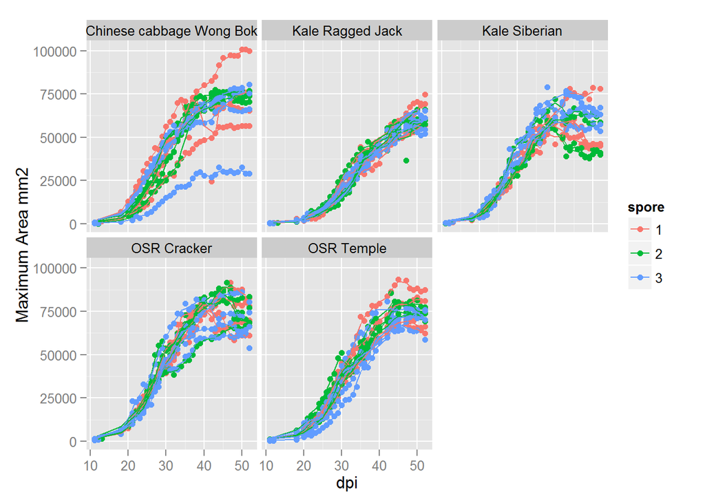

```r
p2<-ggplot(data=subdata,aes(x=dpi,y=Area_mm2,color=spore,group=BR_code))+geom_point()
p2<-p2+geom_line(data=subdata,aes(x=dpi,y=area_ravg,colour=spore,group=BR_code))
p2<-p2+scale_y_continuous(name="Maximum Area mm2")
p2<-p2+facet_wrap(~plant_name)
p2
```

Now get some parameters from the data

```r
#get the maximum values  - sort by area rolling average
sort_subdata<-subdata[order(subdata$BR_code,subdata$area_ravg,na.last=TRUE,decreasing=TRUE),]
#create a vector to hold data by groups
grp<-group_by(sort_subdata,BR_code)
#get the mean of the msz th largest values
d<-summarise(grp,area_mean_ravg=mean(area_ravg[1:msz],na.rm=TRUE))
d
```

```
## Source: local data frame [60 x 2]
##
##      BR_code area_mean_ravg
##       (fctr)          (dbl)
## 1  BR7-01111       76848.44
## 2  BR7-01112       81693.67
## 3  BR7-01113       75093.00
## 4  BR7-01114       88771.56
## 5  BR7-01121       88153.67
## 6  BR7-01122       86114.11
## 7  BR7-01123       66157.89
## 8  BR7-01124       81156.56
## 9  BR7-01131       85360.22
## 10 BR7-01132       80170.56
## ..       ...            ...
```

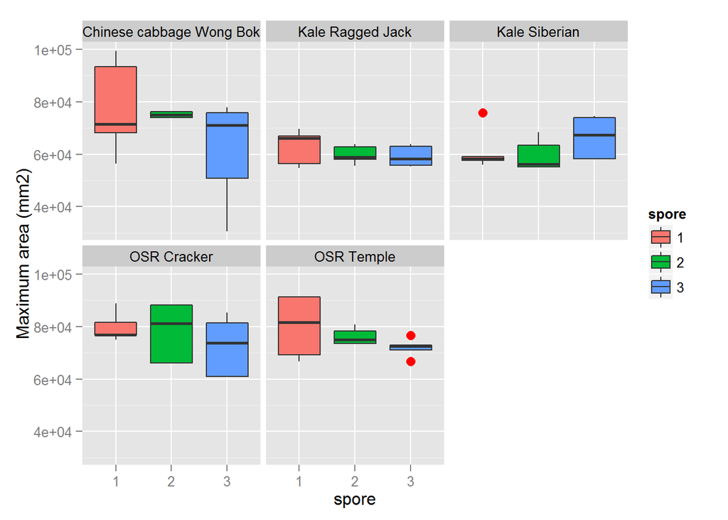

```r
#merge
subdata<-merge(subdata,d,by="BR_code")


#plot the maximum area attained
p2<-ggplot(subdata,aes(x=spore,area_mean_ravg))
p2<-p2+geom_boxplot(aes(fill=spore),outlier.colour="red",outlier.size=3)
p2<-p2+scale_y_continuous(name="Maximum area (mm2)")
p2<-p2+facet_wrap(~plant_name)
p2
```

However, the maximum area is not the final area when measurements were taken Get these as well

```r
#get the final values - sort on dpi
sort_subdata<-subdata[order(subdata$BR_code,subdata$dpi,na.last =TRUE,decreasing=TRUE),]
#create a vector to hold data by groups
grp<-group_by(sort_subdata,BR_code)
#get the mean of the msz th largest values
e<-summarise(grp,area_mean_final=mean(Area_mm2[1:msz],na.rm=TRUE))
e
```

```
## Source: local data frame [60 x 2]
##
##      BR_code area_mean_final
##       (fctr)           (dbl)
## 1  BR7-01111        61203.00
## 2  BR7-01112        78805.33
## 3  BR7-01113        69067.00
## 4  BR7-01114        84254.67
## 5  BR7-01121        75234.67
## 6  BR7-01122        82738.33
## 7  BR7-01123        66727.00
## 8  BR7-01124        69361.67
## 9  BR7-01131        84142.33
## 10 BR7-01132        73191.00
## ..       ...             ...
```

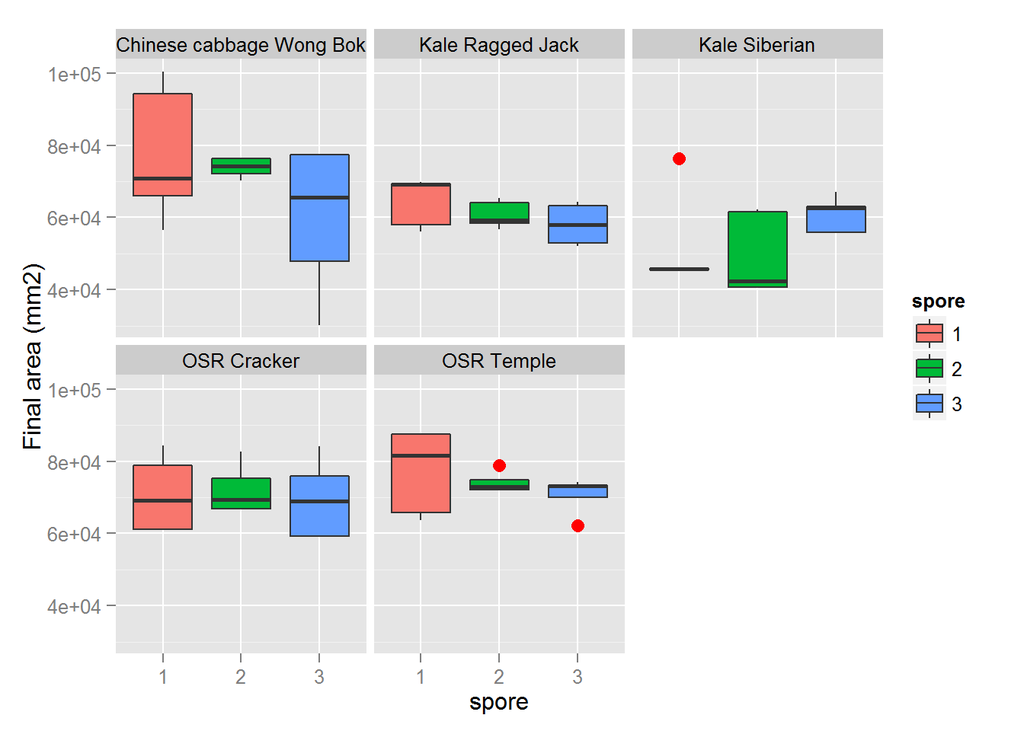

```r
subdata<-merge(subdata,e,by="BR_code")

#plot the maximum area attained
p2<-ggplot(subdata,aes(x=spore,area_mean_final))
p2<-p2+geom_boxplot(aes(fill=spore),outlier.colour="red",outlier.size=3)
p2<-p2+scale_y_continuous(name="Final area (mm2)")
p2<-p2+facet_wrap(~plant_name)
p2
```

Compare the two different measurements

```r
e<-merge(e,d,by="BR_code")
head(e)
```

```
##     BR_code area_mean_final area_mean_ravg
## 1 BR7-01111        61203.00       76848.44
## 2 BR7-01112        78805.33       81693.67
## 3 BR7-01113        69067.00       75093.00
## 4 BR7-01114        84254.67       88771.56
## 5 BR7-01121        75234.67       88153.67
## 6 BR7-01122        82738.33       86114.11
```

```r
#now set the factors manually - it's a bit ugly to set these values again rather than read them from subdata!
e$BR_code<-as.factor(e$BR_code)

#and set the plants,spores,etc
#the plant code is the sixth character in the BR7 string
e$plant<-as.factor(substr(e$BR_code,6,6))
#the spore concentration code is the 8th character
e$spore<-as.factor(substr(e$BR_code,8,8))
#the repeat is the 9th
e$rep<-as.factor(substr(e$BR_code,9,9))
head(e)
```

```
##     BR_code area_mean_final area_mean_ravg plant spore rep
## 1 BR7-01111        61203.00       76848.44     1     1   1
## 2 BR7-01112        78805.33       81693.67     1     1   2
## 3 BR7-01113        69067.00       75093.00     1     1   3
## 4 BR7-01114        84254.67       88771.56     1     1   4
## 5 BR7-01121        75234.67       88153.67     1     2   1
## 6 BR7-01122        82738.33       86114.11     1     2   2
```

```r
#now merge the plant names with the data frame
e<-merge(e,plant_codes,by.x="plant",by.y="plant_code")
head(e)
```

```
##   plant   BR_code area_mean_final area_mean_ravg spore rep  plant_name
## 1     1 BR7-01111        61203.00       76848.44     1   1 OSR Cracker
## 2     1 BR7-01112        78805.33       81693.67     1   2 OSR Cracker
## 3     1 BR7-01113        69067.00       75093.00     1   3 OSR Cracker
## 4     1 BR7-01114        84254.67       88771.56     1   4 OSR Cracker
## 5     1 BR7-01121        75234.67       88153.67     2   1 OSR Cracker
## 6     1 BR7-01122        82738.33       86114.11     2   2 OSR Cracker
##      ASSYST
## 1 Sheff-001
## 2 Sheff-001
## 3 Sheff-001
## 4 Sheff-001
## 5 Sheff-001
## 6 Sheff-001
```

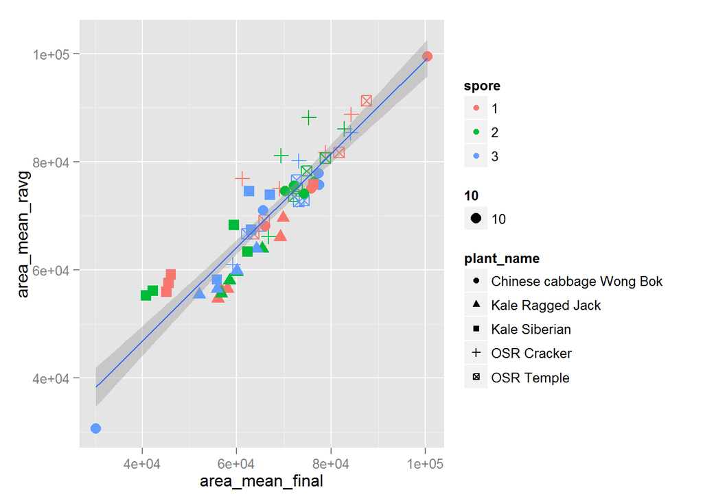

```r
p3<-ggplot(e,aes(x=area_mean_final,y=area_mean_ravg))
p3<-p3+geom_point(aes(colour=spore,shape=plant_name,size=10))
p3<-p3+geom_smooth(method=lm)
p3
```

```r
write.csv(e,file=output_file)
```